# R Notebook: for Lab 8

Neil Yetz

# Clear Environment

```r
rm(list = ls(all.names = TRUE))
```

# Load Libraries

```r
library(tidyverse)
library(psych)
library(GPArotation)
library(GGally)
```

# Load & Format Data

```r
#Original Items (ID removed)
items <- read_csv("Lab 8 Data.csv") %>%
  select(-X1)
#ID's = X1
#Items with item 2 removed
new <- items %>%
  select(-V2)
#Items with item 6 removed
new2 <- items %>%
  select(-V6)
```

# Analyses with All Items

## Scree Plot

```
Parallel analysis suggests that the number of factors =  1  and the number of components =  NA
```

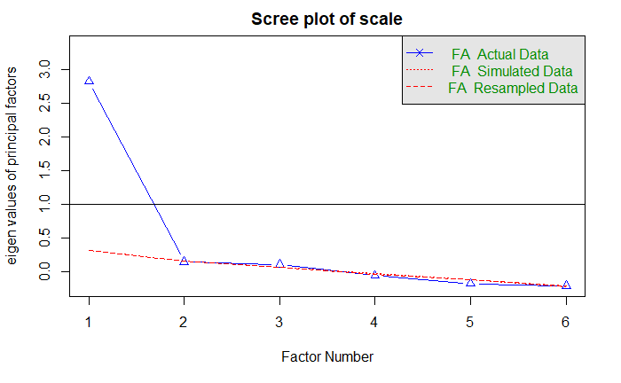

```r
set.seed(123)
parallel = fa.parallel(items,
 fm = 'ml',
 fa = 'fa',
 n.iter = 50,
 main = "Scree plot of scale",
 SMC = TRUE)
```

## Scatterplot + Correlations

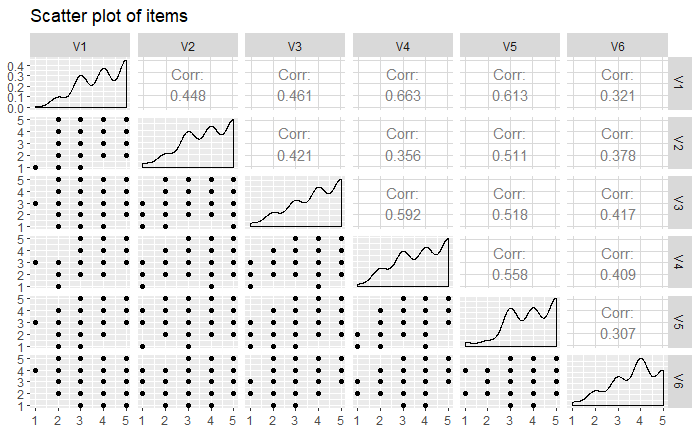

```r
scatterplot <- ggpairs(items, columns = c("V1","V2","V3","V4","V5","V6"),
upper = list(continuous = wrap("cor")),
title = "Scatter plot of items")
print(scatterplot, progress=FALSE)
```

```r
#Easy to read Quick Correlations
cor(items)
```

```
          V1        V2        V3        V4        V5        V6
V1 1.0000000 0.4475946 0.4607503 0.6631835 0.6127996 0.3208026
V2 0.4475946 1.0000000 0.4214397 0.3555404 0.5109323 0.3783689
V3 0.4607503 0.4214397 1.0000000 0.5924146 0.5177870 0.4174004
V4 0.6631835 0.3555404 0.5924146 1.0000000 0.5578658 0.4089589
V5 0.6127996 0.5109323 0.5177870 0.5578658 1.0000000 0.3068259
V6 0.3208026 0.3783689 0.4174004 0.4089589 0.3068259 1.0000000
```

## oblique rotation

### 1 factor

```r
fa(items, nfactors = 1, fm = "ml", rotate = "geominQ")
```

```
Factor Analysis using method =  ml
Call: fa(r = items, nfactors = 1, rotate = "geominQ", fm = "ml")
Standardized loadings (pattern matrix) based upon correlation matrix
    ML1   h2   u2 com
V1 0.78 0.61 0.39   1
V2 0.58 0.33 0.67   1
V3 0.69 0.48 0.52   1
V4 0.80 0.63 0.37   1
V5 0.75 0.56 0.44   1
V6 0.49 0.24 0.76   1

                ML1
SS loadings    2.85
Proportion Var 0.48

Mean item complexity =  1
Test of the hypothesis that 1 factor is sufficient.

The degrees of freedom for the null model are  15  and the objective function was  2.31 with Chi Square of  337.04
The degrees of freedom for the model are 9  and the objective function was  0.2

The root mean square of the residuals (RMSR) is  0.06
The df corrected root mean square of the residuals is  0.08

The harmonic number of observations is  150 with the empirical chi square  15.7  with prob <  0.073
The total number of observations was  150  with Likelihood Chi Square =  28.98  with prob <  0.00065

Tucker Lewis Index of factoring reliability =  0.896
RMSEA index =  0.124  and the 90 % confidence intervals are  0.074 0.173
BIC =  -16.12
Fit based upon off diagonal values = 0.98
Measures of factor score adequacy
                                                   ML1
Correlation of (regression) scores with factors   0.93
Multiple R square of scores with factors          0.86
Minimum correlation of possible factor scores     0.73
```

### 2 factor

```r
fa(items, nfactors = 2, fm = "ml", rotate = "geominQ")
```

```
Factor Analysis using method =  ml
Call: fa(r = items, nfactors = 2, rotate = "geominQ", fm = "ml")
Standardized loadings (pattern matrix) based upon correlation matrix
    ML2   ML1   h2    u2 com
V1 0.47  0.37 0.57 0.427 1.9
V2 0.78 -0.14 0.50 0.504 1.1
V3 0.43  0.32 0.46 0.536 1.8
V4 0.01  0.99 1.00 0.005 1.0
V5 0.70  0.12 0.60 0.397 1.1
V6 0.35  0.19 0.24 0.759 1.5

                       ML2  ML1
SS loadings           1.86 1.51
Proportion Var        0.31 0.25
Cumulative Var        0.31 0.56
Proportion Explained  0.55 0.45
Cumulative Proportion 0.55 1.00

 With factor correlations of
     ML2  ML1
ML2 1.00 0.63
ML1 0.63 1.00

Mean item complexity =  1.4
Test of the hypothesis that 2 factors are sufficient.

The degrees of freedom for the null model are  15  and the objective function was  2.31 with Chi Square of  337.04
The degrees of freedom for the model are 4  and the objective function was  0.08

The root mean square of the residuals (RMSR) is  0.04
The df corrected root mean square of the residuals is  0.08

The harmonic number of observations is  150 with the empirical chi square  7.27  with prob <  0.12
The total number of observations was  150  with Likelihood Chi Square =  11.05  with prob <  0.026

Tucker Lewis Index of factoring reliability =  0.917
RMSEA index =  0.111  and the 90 % confidence intervals are  0.034 0.188
BIC =  -8.99
Fit based upon off diagonal values = 0.99
Measures of factor score adequacy
                                                   ML2  ML1
Correlation of (regression) scores with factors   0.90 1.00
Multiple R square of scores with factors          0.80 0.99
Minimum correlation of possible factor scores     0.61 0.99
```

## orthoganol rotation

### 1 factor

```r
fa(items, nfactors = 1, fm = "ml", rotate = "geominT")
```

```
Factor Analysis using method =  ml
Call: fa(r = items, nfactors = 1, rotate = "geominT", fm = "ml")
Standardized loadings (pattern matrix) based upon correlation matrix
    ML1   h2   u2 com
V1 0.78 0.61 0.39   1
V2 0.58 0.33 0.67   1
V3 0.69 0.48 0.52   1
V4 0.80 0.63 0.37   1
V5 0.75 0.56 0.44   1
V6 0.49 0.24 0.76   1

                ML1
SS loadings    2.85
Proportion Var 0.48

Mean item complexity =  1
Test of the hypothesis that 1 factor is sufficient.

The degrees of freedom for the null model are  15  and the objective function was  2.31 with Chi Square of  337.04
The degrees of freedom for the model are 9  and the objective function was  0.2

The root mean square of the residuals (RMSR) is  0.06
The df corrected root mean square of the residuals is  0.08

The harmonic number of observations is  150 with the empirical chi square  15.7  with prob <  0.073
The total number of observations was  150  with Likelihood Chi Square =  28.98  with prob <  0.00065

Tucker Lewis Index of factoring reliability =  0.896
RMSEA index =  0.124  and the 90 % confidence intervals are  0.074 0.173
BIC =  -16.12
Fit based upon off diagonal values = 0.98
Measures of factor score adequacy
                                                   ML1
Correlation of (regression) scores with factors   0.93
Multiple R square of scores with factors          0.86
Minimum correlation of possible factor scores     0.73
```

### 2 factor

```r
fa(items, nfactors = 2, fm = "ml", rotate = "geominT")
```

```
Factor Analysis using method =  ml
Call: fa(r = items, nfactors = 2, rotate = "geominT", fm = "ml")
Standardized loadings (pattern matrix) based upon correlation matrix
    ML1   ML2   h2    u2 com
V1 0.76  0.04 0.57 0.427 1.0
V2 0.62 -0.33 0.50 0.504 1.5
V3 0.68  0.03 0.46 0.536 1.0
V4 0.85  0.52 1.00 0.005 1.7
V5 0.76 -0.17 0.60 0.397 1.1
V6 0.49 -0.02 0.24 0.759 1.0

                       ML1  ML2
SS loadings           2.96 0.41
Proportion Var        0.49 0.07
Cumulative Var        0.49 0.56
Proportion Explained  0.88 0.12
Cumulative Proportion 0.88 1.00

Mean item complexity =  1.2
Test of the hypothesis that 2 factors are sufficient.

The degrees of freedom for the null model are  15  and the objective function was  2.31 with Chi Square of  337.04
The degrees of freedom for the model are 4  and the objective function was  0.08

The root mean square of the residuals (RMSR) is  0.04
The df corrected root mean square of the residuals is  0.08

The harmonic number of observations is  150 with the empirical chi square  7.27  with prob <  0.12
The total number of observations was  150  with Likelihood Chi Square =  11.05  with prob <  0.026

Tucker Lewis Index of factoring reliability =  0.917
RMSEA index =  0.111  and the 90 % confidence intervals are  0.034 0.188
BIC =  -8.99
Fit based upon off diagonal values = 0.99
Measures of factor score adequacy
                                                   ML1  ML2
Correlation of (regression) scores with factors   0.95 0.87
Multiple R square of scores with factors          0.91 0.76
Minimum correlation of possible factor scores     0.82 0.51
```

## varimax rotation

### 1 factor

```r
fa(items, nfactors = 1, fm = "ml", rotate = "varimax")
```

```
Factor Analysis using method =  ml
Call: fa(r = items, nfactors = 1, rotate = "varimax", fm = "ml")
Standardized loadings (pattern matrix) based upon correlation matrix
    ML1   h2   u2 com
V1 0.78 0.61 0.39   1
V2 0.58 0.33 0.67   1
V3 0.69 0.48 0.52   1
V4 0.80 0.63 0.37   1
V5 0.75 0.56 0.44   1
V6 0.49 0.24 0.76   1

                ML1
SS loadings    2.85
Proportion Var 0.48

Mean item complexity =  1
Test of the hypothesis that 1 factor is sufficient.

The degrees of freedom for the null model are  15  and the objective function was  2.31 with Chi Square of  337.04
The degrees of freedom for the model are 9  and the objective function was  0.2

The root mean square of the residuals (RMSR) is  0.06
The df corrected root mean square of the residuals is  0.08

The harmonic number of observations is  150 with the empirical chi square  15.7  with prob <  0.073
The total number of observations was  150  with Likelihood Chi Square =  28.98  with prob <  0.00065

Tucker Lewis Index of factoring reliability =  0.896
RMSEA index =  0.124  and the 90 % confidence intervals are  0.074 0.173
BIC =  -16.12
Fit based upon off diagonal values = 0.98
Measures of factor score adequacy
                                                   ML1
Correlation of (regression) scores with factors   0.93
Multiple R square of scores with factors          0.86
Minimum correlation of possible factor scores     0.73
```

### 2 factor

```r
fa(items, nfactors = 2, fm = "ml", rotate = "varimax")
```

```
Factor Analysis using method =  ml
Call: fa(r = items, nfactors = 2, rotate = "varimax", fm = "ml")
Standardized loadings (pattern matrix) based upon correlation matrix
    ML1  ML2   h2    u2 com
V1 0.54 0.53 0.57 0.427 2.0
V2 0.17 0.68 0.50 0.504 1.1
V3 0.48 0.49 0.46 0.536 2.0
V4 0.96 0.28 1.00 0.005 1.2
V5 0.39 0.67 0.60 0.397 1.6
V6 0.32 0.37 0.24 0.759 2.0

                       ML1  ML2
SS loadings           1.72 1.65
Proportion Var        0.29 0.28
Cumulative Var        0.29 0.56
Proportion Explained  0.51 0.49
Cumulative Proportion 0.51 1.00

Mean item complexity =  1.6
Test of the hypothesis that 2 factors are sufficient.

The degrees of freedom for the null model are  15  and the objective function was  2.31 with Chi Square of  337.04
The degrees of freedom for the model are 4  and the objective function was  0.08

The root mean square of the residuals (RMSR) is  0.04
The df corrected root mean square of the residuals is  0.08

The harmonic number of observations is  150 with the empirical chi square  7.27  with prob <  0.12
The total number of observations was  150  with Likelihood Chi Square =  11.05  with prob <  0.026

Tucker Lewis Index of factoring reliability =  0.917
RMSEA index =  0.111  and the 90 % confidence intervals are  0.034 0.188
BIC =  -8.99
Fit based upon off diagonal values = 0.99
Measures of factor score adequacy
                                                   ML1  ML2
Correlation of (regression) scores with factors   0.98 0.84
Multiple R square of scores with factors          0.97 0.70
Minimum correlation of possible factor scores     0.94 0.40
```

# Analyses with Item 2 Removed

Based on the original Correlation Matrix, I decided to also try and run analyses with the removal of Item 2. **Conclusion:** Remove Item 2

## Scree Plot

```
Parallel analysis suggests that the number of factors =  1  and the number of components =  NA
```

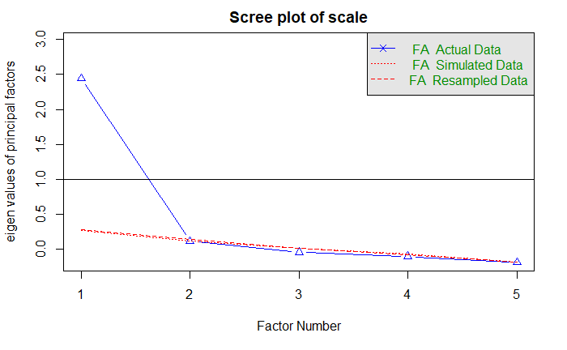

```r
set.seed(123)
parallel = fa.parallel(new,
 fm = 'ml',
 fa = 'fa',
 n.iter = 50,
 main = "Scree plot of scale",
 SMC = TRUE)
```

## Scatterplot + Correlations

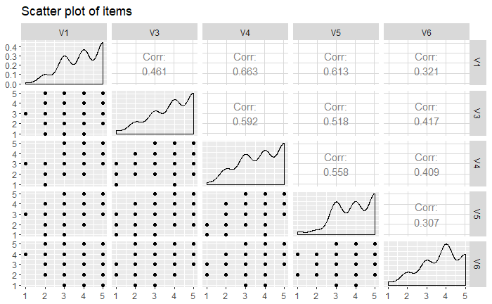

```r
scatterplot <- ggpairs(new, columns = c("V1","V3","V4","V5","V6"),
upper = list(continuous = wrap("cor")),
title = "Scatter plot of items")
print(scatterplot, progress=FALSE)
```

```r
#Easy to read Quick Correlations
cor(new)
```

```
          V1        V3        V4        V5        V6
V1 1.0000000 0.4607503 0.6631835 0.6127996 0.3208026
V3 0.4607503 1.0000000 0.5924146 0.5177870 0.4174004
V4 0.6631835 0.5924146 1.0000000 0.5578658 0.4089589
V5 0.6127996 0.5177870 0.5578658 1.0000000 0.3068259
V6 0.3208026 0.4174004 0.4089589 0.3068259 1.0000000
```

## oblique rotation

### 1 factor

```r
fa(new, nfactors = 1, fm = "ml", rotate = "geominQ")
```

```
Factor Analysis using method =  ml
Call: fa(r = new, nfactors = 1, rotate = "geominQ", fm = "ml")
Standardized loadings (pattern matrix) based upon correlation matrix
    ML1   h2   u2 com
V1 0.78 0.60 0.40   1
V3 0.69 0.47 0.53   1
V4 0.83 0.70 0.30   1
V5 0.72 0.52 0.48   1
V6 0.48 0.23 0.77   1

                ML1
SS loadings    2.51
Proportion Var 0.50

Mean item complexity =  1
Test of the hypothesis that 1 factor is sufficient.

The degrees of freedom for the null model are  10  and the objective function was  1.88 with Chi Square of  274.89
The degrees of freedom for the model are 5  and the objective function was  0.09

The root mean square of the residuals (RMSR) is  0.05
The df corrected root mean square of the residuals is  0.07

The harmonic number of observations is  150 with the empirical chi square  6.93  with prob <  0.23
The total number of observations was  150  with Likelihood Chi Square =  13.66  with prob <  0.018

Tucker Lewis Index of factoring reliability =  0.934
RMSEA index =  0.11  and the 90 % confidence intervals are  0.041 0.178
BIC =  -11.39
Fit based upon off diagonal values = 0.99
Measures of factor score adequacy
                                                   ML1
Correlation of (regression) scores with factors   0.93
Multiple R square of scores with factors          0.86
Minimum correlation of possible factor scores     0.72
```

### 2 factor

```r
fa(new, nfactors = 2, fm = "ml", rotate = "geominQ")
```

```
Factor Analysis using method =  ml
Call: fa(r = new, nfactors = 2, rotate = "geominQ", fm = "ml")
Standardized loadings (pattern matrix) based upon correlation matrix
    ML2   ML1   h2    u2 com
V1 0.00  1.00 1.00 0.005 1.0
V3 0.83 -0.04 0.65 0.350 1.0
V4 0.55  0.33 0.63 0.365 1.7
V5 0.43  0.36 0.49 0.506 1.9
V6 0.51  0.02 0.27 0.731 1.0

                       ML2  ML1
SS loadings           1.62 1.42
Proportion Var        0.32 0.28
Cumulative Var        0.32 0.61
Proportion Explained  0.53 0.47
Cumulative Proportion 0.53 1.00

 With factor correlations of
    ML2 ML1
ML2 1.0 0.6
ML1 0.6 1.0

Mean item complexity =  1.3
Test of the hypothesis that 2 factors are sufficient.

The degrees of freedom for the null model are  10  and the objective function was  1.88 with Chi Square of  274.89
The degrees of freedom for the model are 1  and the objective function was  0

The root mean square of the residuals (RMSR) is  0.01
The df corrected root mean square of the residuals is  0.04

The harmonic number of observations is  150 with the empirical chi square  0.37  with prob <  0.54
The total number of observations was  150  with Likelihood Chi Square =  0.58  with prob <  0.45

Tucker Lewis Index of factoring reliability =  1.016
RMSEA index =  0  and the 90 % confidence intervals are  0 0.196
BIC =  -4.43
Fit based upon off diagonal values = 1
Measures of factor score adequacy
                                                  ML2  ML1
Correlation of (regression) scores with factors   0.9 1.00
Multiple R square of scores with factors          0.8 1.00
Minimum correlation of possible factor scores     0.6 0.99
```

## orthoganol rotation

### 1 factor

```r
fa(new, nfactors = 1, fm = "ml", rotate = "geominT")
```

```
Factor Analysis using method =  ml
Call: fa(r = new, nfactors = 1, rotate = "geominT", fm = "ml")
Standardized loadings (pattern matrix) based upon correlation matrix
    ML1   h2   u2 com
V1 0.78 0.60 0.40   1
V3 0.69 0.47 0.53   1
V4 0.83 0.70 0.30   1
V5 0.72 0.52 0.48   1
V6 0.48 0.23 0.77   1

                ML1
SS loadings    2.51
Proportion Var 0.50

Mean item complexity =  1
Test of the hypothesis that 1 factor is sufficient.

The degrees of freedom for the null model are  10  and the objective function was  1.88 with Chi Square of  274.89
The degrees of freedom for the model are 5  and the objective function was  0.09

The root mean square of the residuals (RMSR) is  0.05
The df corrected root mean square of the residuals is  0.07

The harmonic number of observations is  150 with the empirical chi square  6.93  with prob <  0.23
The total number of observations was  150  with Likelihood Chi Square =  13.66  with prob <  0.018

Tucker Lewis Index of factoring reliability =  0.934
RMSEA index =  0.11  and the 90 % confidence intervals are  0.041 0.178
BIC =  -11.39
Fit based upon off diagonal values = 0.99
Measures of factor score adequacy
                                                   ML1
Correlation of (regression) scores with factors   0.93
Multiple R square of scores with factors          0.86
Minimum correlation of possible factor scores     0.72
```

### 2 factor

```r
fa(new, nfactors = 2, fm = "ml", rotate = "geominT")
```

```
Factor Analysis using method =  ml
Call: fa(r = new, nfactors = 2, rotate = "geominT", fm = "ml")
Standardized loadings (pattern matrix) based upon correlation matrix
    ML1   ML2   h2    u2 com
V1 1.00 -0.04 1.00 0.005 1.0
V3 0.49  0.64 0.65 0.350 1.9
V4 0.68  0.41 0.63 0.365 1.6
V5 0.63  0.32 0.49 0.506 1.5
V6 0.34  0.39 0.27 0.731 2.0

                       ML1  ML2
SS loadings           2.20 0.84
Proportion Var        0.44 0.17
Cumulative Var        0.44 0.61
Proportion Explained  0.72 0.28
Cumulative Proportion 0.72 1.00

Mean item complexity =  1.6
Test of the hypothesis that 2 factors are sufficient.

The degrees of freedom for the null model are  10  and the objective function was  1.88 with Chi Square of  274.89
The degrees of freedom for the model are 1  and the objective function was  0

The root mean square of the residuals (RMSR) is  0.01
The df corrected root mean square of the residuals is  0.04

The harmonic number of observations is  150 with the empirical chi square  0.37  with prob <  0.54
The total number of observations was  150  with Likelihood Chi Square =  0.58  with prob <  0.45

Tucker Lewis Index of factoring reliability =  1.016
RMSEA index =  0  and the 90 % confidence intervals are  0 0.196
BIC =  -4.43
Fit based upon off diagonal values = 1
Measures of factor score adequacy
                                                   ML1  ML2
Correlation of (regression) scores with factors   1.00 0.83
Multiple R square of scores with factors          0.99 0.69
Minimum correlation of possible factor scores     0.99 0.38
```

## varimax rotation

### 1 factor

```r
fa(new, nfactors = 1, fm = "ml", rotate = "varimax")
```

```
Factor Analysis using method =  ml
Call: fa(r = new, nfactors = 1, rotate = "varimax", fm = "ml")
Standardized loadings (pattern matrix) based upon correlation matrix
    ML1   h2   u2 com
V1 0.78 0.60 0.40   1
V3 0.69 0.47 0.53   1
V4 0.83 0.70 0.30   1
V5 0.72 0.52 0.48   1
V6 0.48 0.23 0.77   1

                ML1
SS loadings    2.51
Proportion Var 0.50

Mean item complexity =  1
Test of the hypothesis that 1 factor is sufficient.

The degrees of freedom for the null model are  10  and the objective function was  1.88 with Chi Square of  274.89
The degrees of freedom for the model are 5  and the objective function was  0.09

The root mean square of the residuals (RMSR) is  0.05
The df corrected root mean square of the residuals is  0.07

The harmonic number of observations is  150 with the empirical chi square  6.93  with prob <  0.23
The total number of observations was  150  with Likelihood Chi Square =  13.66  with prob <  0.018

Tucker Lewis Index of factoring reliability =  0.934
RMSEA index =  0.11  and the 90 % confidence intervals are  0.041 0.178
BIC =  -11.39
Fit based upon off diagonal values = 0.99
Measures of factor score adequacy
                                                   ML1
Correlation of (regression) scores with factors   0.93
Multiple R square of scores with factors          0.86
Minimum correlation of possible factor scores     0.72
```

### 2 factor

```r
fa(new, nfactors = 2, fm = "ml", rotate = "varimax")
```

```
Factor Analysis using method =  ml
Call: fa(r = new, nfactors = 2, rotate = "varimax", fm = "ml")
Standardized loadings (pattern matrix) based upon correlation matrix
    ML2  ML1   h2    u2 com
V1 0.30 0.95 1.00 0.005 1.2
V3 0.77 0.24 0.65 0.350 1.2
V4 0.62 0.50 0.63 0.365 1.9
V5 0.51 0.48 0.49 0.506 2.0
V6 0.48 0.19 0.27 0.731 1.3

                       ML2  ML1
SS loadings           1.55 1.49
Proportion Var        0.31 0.30
Cumulative Var        0.31 0.61
Proportion Explained  0.51 0.49
Cumulative Proportion 0.51 1.00

Mean item complexity =  1.5
Test of the hypothesis that 2 factors are sufficient.

The degrees of freedom for the null model are  10  and the objective function was  1.88 with Chi Square of  274.89
The degrees of freedom for the model are 1  and the objective function was  0

The root mean square of the residuals (RMSR) is  0.01
The df corrected root mean square of the residuals is  0.04

The harmonic number of observations is  150 with the empirical chi square  0.37  with prob <  0.54
The total number of observations was  150  with Likelihood Chi Square =  0.58  with prob <  0.45

Tucker Lewis Index of factoring reliability =  1.016
RMSEA index =  0  and the 90 % confidence intervals are  0 0.196
BIC =  -4.43
Fit based upon off diagonal values = 1
Measures of factor score adequacy
                                                   ML2  ML1
Correlation of (regression) scores with factors   0.85 0.98
Multiple R square of scores with factors          0.72 0.97
Minimum correlation of possible factor scores     0.44 0.93
```

# Analyses with Item 6 Removed

Based on the original Correlation Matrix, I decided to also try and run analyses with the removal of Item 6. **Main Conclusion**: We should keep item 6

## Scree Plot

```
Parallel analysis suggests that the number of factors =  1  and the number of components =  NA
```

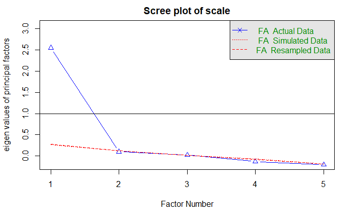

```r
set.seed(123)
parallel = fa.parallel(new2,
 fm = 'ml',
 fa = 'fa',
 n.iter = 50,
 main = "Scree plot of scale",
 SMC = TRUE)
```

## Scatterplot + Correlations

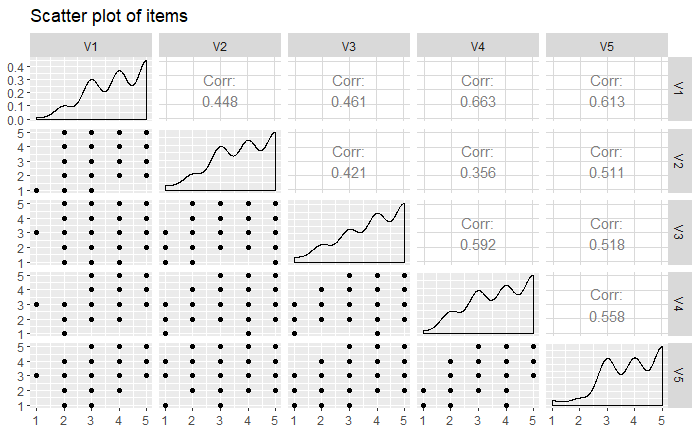

```r
scatterplot <- ggpairs(new2, columns = c("V1","V2","V3","V4","V5"),
upper = list(continuous = wrap("cor")),
title = "Scatter plot of items")
print(scatterplot, progress=FALSE)
```

```r
#Easy to read Quick Correlations
cor(new2)
```

```
          V1        V2        V3        V4        V5
V1 1.0000000 0.4475946 0.4607503 0.6631835 0.6127996
V2 0.4475946 1.0000000 0.4214397 0.3555404 0.5109323
V3 0.4607503 0.4214397 1.0000000 0.5924146 0.5177870
V4 0.6631835 0.3555404 0.5924146 1.0000000 0.5578658
V5 0.6127996 0.5109323 0.5177870 0.5578658 1.0000000
```

## oblique rotation

### 1 factor

```r
fa(new2, nfactors = 1, fm = "ml", rotate = "geominQ")
```

```
Factor Analysis using method =  ml
Call: fa(r = new2, nfactors = 1, rotate = "geominQ", fm = "ml")
Standardized loadings (pattern matrix) based upon correlation matrix
    ML1   h2   u2 com
V1 0.79 0.63 0.37   1
V2 0.57 0.32 0.68   1
V3 0.68 0.46 0.54   1
V4 0.79 0.62 0.38   1
V5 0.76 0.58 0.42   1

                ML1
SS loadings    2.61
Proportion Var 0.52

Mean item complexity =  1
Test of the hypothesis that 1 factor is sufficient.

The degrees of freedom for the null model are  10  and the objective function was  2.01 with Chi Square of  294.82
The degrees of freedom for the model are 5  and the objective function was  0.13

The root mean square of the residuals (RMSR) is  0.05
The df corrected root mean square of the residuals is  0.08

The harmonic number of observations is  150 with the empirical chi square  8.61  with prob <  0.13
The total number of observations was  150  with Likelihood Chi Square =  19.58  with prob <  0.0015

Tucker Lewis Index of factoring reliability =  0.897
RMSEA index =  0.142  and the 90 % confidence intervals are  0.078 0.208
BIC =  -5.48
Fit based upon off diagonal values = 0.99
Measures of factor score adequacy
                                                   ML1
Correlation of (regression) scores with factors   0.93
Multiple R square of scores with factors          0.86
Minimum correlation of possible factor scores     0.72
```

### 2 factor

```r
fa(new2, nfactors = 2, fm = "ml", rotate = "geominQ")
```

```
Factor Analysis using method =  ml
Call: fa(r = new2, nfactors = 2, rotate = "geominQ", fm = "ml")
Standardized loadings (pattern matrix) based upon correlation matrix
    ML2   ML1   h2    u2 com
V1 0.50  0.34 0.59 0.414 1.8
V2 0.71 -0.10 0.42 0.576 1.0
V3 0.40  0.33 0.45 0.554 1.9
V4 0.01  0.99 1.00 0.005 1.0
V5 0.78  0.05 0.67 0.329 1.0

                       ML2  ML1
SS loadings           1.72 1.40
Proportion Var        0.34 0.28
Cumulative Var        0.34 0.62
Proportion Explained  0.55 0.45
Cumulative Proportion 0.55 1.00

 With factor correlations of
     ML2  ML1
ML2 1.00 0.64
ML1 0.64 1.00

Mean item complexity =  1.3
Test of the hypothesis that 2 factors are sufficient.

The degrees of freedom for the null model are  10  and the objective function was  2.01 with Chi Square of  294.82
The degrees of freedom for the model are 1  and the objective function was  0.02

The root mean square of the residuals (RMSR) is  0.02
The df corrected root mean square of the residuals is  0.07

The harmonic number of observations is  150 with the empirical chi square  1.44  with prob <  0.23
The total number of observations was  150  with Likelihood Chi Square =  2.87  with prob <  0.09

Tucker Lewis Index of factoring reliability =  0.934
RMSEA index =  0.114  and the 90 % confidence intervals are  0 0.274
BIC =  -2.14
Fit based upon off diagonal values = 1
Measures of factor score adequacy
                                                   ML2  ML1
Correlation of (regression) scores with factors   0.90 1.00
Multiple R square of scores with factors          0.81 0.99
Minimum correlation of possible factor scores     0.63 0.99
```

## orthoganol rotation

### 1 factor

```r
fa(new2, nfactors = 1, fm = "ml", rotate = "geominT")
```

```
Factor Analysis using method =  ml
Call: fa(r = new2, nfactors = 1, rotate = "geominT", fm = "ml")
Standardized loadings (pattern matrix) based upon correlation matrix
    ML1   h2   u2 com
V1 0.79 0.63 0.37   1
V2 0.57 0.32 0.68   1
V3 0.68 0.46 0.54   1
V4 0.79 0.62 0.38   1
V5 0.76 0.58 0.42   1

                ML1
SS loadings    2.61
Proportion Var 0.52

Mean item complexity =  1
Test of the hypothesis that 1 factor is sufficient.

The degrees of freedom for the null model are  10  and the objective function was  2.01 with Chi Square of  294.82
The degrees of freedom for the model are 5  and the objective function was  0.13

The root mean square of the residuals (RMSR) is  0.05
The df corrected root mean square of the residuals is  0.08

The harmonic number of observations is  150 with the empirical chi square  8.61  with prob <  0.13
The total number of observations was  150  with Likelihood Chi Square =  19.58  with prob <  0.0015

Tucker Lewis Index of factoring reliability =  0.897
RMSEA index =  0.142  and the 90 % confidence intervals are  0.078 0.208
BIC =  -5.48
Fit based upon off diagonal values = 0.99
Measures of factor score adequacy
                                                   ML1
Correlation of (regression) scores with factors   0.93
Multiple R square of scores with factors          0.86
Minimum correlation of possible factor scores     0.72
```

### 2 factor

```r
fa(new2, nfactors = 2, fm = "ml", rotate = "geominT")
```

```
Factor Analysis using method =  ml
Call: fa(r = new2, nfactors = 2, rotate = "geominT", fm = "ml")
Standardized loadings (pattern matrix) based upon correlation matrix
    ML1   ML2   h2    u2 com
V1 0.69  0.33 0.59 0.414 1.4
V2 0.40  0.52 0.42 0.576 1.9
V3 0.61  0.26 0.45 0.554 1.3
V4 0.99 -0.07 1.00 0.005 1.0
V5 0.60  0.56 0.67 0.329 2.0

                       ML1  ML2
SS loadings           2.36 0.76
Proportion Var        0.47 0.15
Cumulative Var        0.47 0.62
Proportion Explained  0.76 0.24
Cumulative Proportion 0.76 1.00

Mean item complexity =  1.5
Test of the hypothesis that 2 factors are sufficient.

The degrees of freedom for the null model are  10  and the objective function was  2.01 with Chi Square of  294.82
The degrees of freedom for the model are 1  and the objective function was  0.02

The root mean square of the residuals (RMSR) is  0.02
The df corrected root mean square of the residuals is  0.07

The harmonic number of observations is  150 with the empirical chi square  1.44  with prob <  0.23
The total number of observations was  150  with Likelihood Chi Square =  2.87  with prob <  0.09

Tucker Lewis Index of factoring reliability =  0.934
RMSEA index =  0.114  and the 90 % confidence intervals are  0 0.274
BIC =  -2.14
Fit based upon off diagonal values = 1
Measures of factor score adequacy
                                                   ML1  ML2
Correlation of (regression) scores with factors   1.00 0.82
Multiple R square of scores with factors          0.99 0.68
Minimum correlation of possible factor scores     0.99 0.36
```

## varimax rotation

### 1 factor

```r
fa(new2, nfactors = 1, fm = "ml", rotate = "varimax")
```

```
Factor Analysis using method =  ml
Call: fa(r = new2, nfactors = 1, rotate = "varimax", fm = "ml")
Standardized loadings (pattern matrix) based upon correlation matrix
    ML1   h2   u2 com
V1 0.79 0.63 0.37   1
V2 0.57 0.32 0.68   1
V3 0.68 0.46 0.54   1
V4 0.79 0.62 0.38   1
V5 0.76 0.58 0.42   1

                ML1
SS loadings    2.61
Proportion Var 0.52

Mean item complexity =  1
Test of the hypothesis that 1 factor is sufficient.

The degrees of freedom for the null model are  10  and the objective function was  2.01 with Chi Square of  294.82
The degrees of freedom for the model are 5  and the objective function was  0.13

The root mean square of the residuals (RMSR) is  0.05
The df corrected root mean square of the residuals is  0.08

The harmonic number of observations is  150 with the empirical chi square  8.61  with prob <  0.13
The total number of observations was  150  with Likelihood Chi Square =  19.58  with prob <  0.0015

Tucker Lewis Index of factoring reliability =  0.897
RMSEA index =  0.142  and the 90 % confidence intervals are  0.078 0.208
BIC =  -5.48
Fit based upon off diagonal values = 0.99
Measures of factor score adequacy
                                                   ML1
Correlation of (regression) scores with factors   0.93
Multiple R square of scores with factors          0.86
Minimum correlation of possible factor scores     0.72
```

### 2 factor

```r
fa(new2, nfactors = 2, fm = "ml", rotate = "varimax")
```

```
Factor Analysis using method =  ml
Call: fa(r = new2, nfactors = 2, rotate = "varimax", fm = "ml")
Standardized loadings (pattern matrix) based upon correlation matrix
    ML1  ML2   h2    u2 com
V1 0.53 0.56 0.59 0.414 2.0
V2 0.18 0.62 0.42 0.576 1.2
V3 0.48 0.46 0.45 0.554 2.0
V4 0.96 0.29 1.00 0.005 1.2
V5 0.36 0.73 0.67 0.329 1.5

                       ML1  ML2
SS loadings           1.59 1.54
Proportion Var        0.32 0.31
Cumulative Var        0.32 0.62
Proportion Explained  0.51 0.49
Cumulative Proportion 0.51 1.00

Mean item complexity =  1.6
Test of the hypothesis that 2 factors are sufficient.

The degrees of freedom for the null model are  10  and the objective function was  2.01 with Chi Square of  294.82
The degrees of freedom for the model are 1  and the objective function was  0.02

The root mean square of the residuals (RMSR) is  0.02
The df corrected root mean square of the residuals is  0.07

The harmonic number of observations is  150 with the empirical chi square  1.44  with prob <  0.23
The total number of observations was  150  with Likelihood Chi Square =  2.87  with prob <  0.09

Tucker Lewis Index of factoring reliability =  0.934
RMSEA index =  0.114  and the 90 % confidence intervals are  0 0.274
BIC =  -2.14
Fit based upon off diagonal values = 1
Measures of factor score adequacy
                                                   ML1  ML2
Correlation of (regression) scores with factors   0.98 0.84
Multiple R square of scores with factors          0.97 0.71
Minimum correlation of possible factor scores     0.93 0.41
```

# Question Answers

## Question 1: How many factors there are in these items.

**1 factor**. Additionally, removing Item 2 (V2). Reasons are explained in Question #3.

## 2. Which items load on which factors (report the factor loadings).

We only had one factor. Therefore, they all loaded onto 1. We removed Item #2, Which left us with items, V1, V3, V4, V5, & V6. Their Oblique rotated (Alhough, it makes no difference in a 1 factor model what rotation you use) factor loadings are respectively **0.775992, 0.6875316, 0.8342174, 0.7191027, 0.4764404**.

## 3. What process and decision rules you used to reach that conclusion.

I have decided that the best solution for this is a 1 factor model. Additionally, I made the decision to remove Item 2. Based on the correlations, and factor loadings. Item 2 did not seem to fit with the other items. You could ustify keeping it in, but I made the decision to leave it out based on certain Criteria. To start, Viewing the correlations from correlation with all items, item 2 did not correlate as well as the other items (Neither, did items 6, so I check onthat one too). Therefore, I investigated the EFA without item 2. Our factor loadings for V1-V6 were respectively 0.7783935, 0.576688, 0.6929275, 0.7951046, 0.7499469, 0.4907968. Without item 2, items V1, V3, V4, V5, & V6 loadings were: 0.775992, 0.6875316, 0.8342174, 0.7191027, 0.4764404 respectively. Although there was a drop in the factor loadings, I felt that the improvement in model fit made it worth it (Explained in the next paragraph).

Finally, with the removal of item 2, I decided to stick with a 1 factor model. I decided on this by first viewing the scree plot Visually, I could tell that the eigen value for 1 factor was sufficiently higher than if we added another factor into the model. Additionally I generated a factor analysis on a random dataset and compared it with the eigen values I generated from a scree plot with 1 factor and 2 factors. Viewing this, it was possible to see that an EFA on a set of random values explains more than if there were 2 factor. Therefore, evidence supporting a 1 factor model. Next, I compared the factor loadings on the 2-factor model (keeping it to the obliquely rotated model) and found it hard to map 2 factors. V1 & V3 seemed to map pretty clear onto separate factors, but the rest didn’t. Additionally, The fit values were a bit odd. an RMSEA of 0 and TLI of 1.016 for the 2-factor model did not sit well with me. Additionally, I prefer the idea of parsimony in my models, and a 1 factor model seemed to be sufficiently explaining the construct.